# The most dangerous weather events in the United States of America

Srijan Nayak

## Synopsis

This analysis aims to determine the most dangerous weather events in the US with respect to population health and economic consequences. The data used for this analysis is taken from the U.S. National Oceanic and Atmospheric Administration’s (NOAA) storm database. The considered data contains events from 1950 to November 2011. This analysis was done as part of a project in a course titled “Reproducible Research” by Johns Hopkins University on Coursera.

## Processing Data

### Loading required libraries

```r
library(dplyr)
library(stringr)
```

### Loading data

```r
download.file(
    "https://d396qusza40orc.cloudfront.net/repdata%2Fdata%2FStormData.csv.bz2",
    destfile = "storm-data.csv.bz2"
)
raw_storms_data <- read.csv("storm-data.csv.bz2") %>% as_tibble()
```

### Selecting required variables

```r
selected_storms_data <- raw_storms_data %>% select(
    EVTYPE,
    FATALITIES,
    INJURIES,
    PROPDMG,
    PROPDMGEXP,
    CROPDMG,
    CROPDMGEXP
)
```

While there are 37 different variables in the original dataset, for the purpose of this analysis, only 7 of them are needed.

### Handling event type typos

```r
valid_evtpyes <- c(
    "Astronomical Low Tide", "Storm Surge/Tide", "Avalanche", "Blizzard",
    "Coastal Flood", "Flash Flood", "Lakeshore Flood", "Flood",
    "Extreme Cold/Wind Chill", "Cold/Wind Chill", "Marine High Wind", "Marine Strong Wind",
    "Marine Thunderstorm Wind", "High Wind", "Strong Wind", "Thunderstorm Wind",
    "Dense Fog", "Freezing Fog", "Frost/Freeze", "Dust Devil",
    "Dust Storm", "Ice Storm", "Tropical Storm", "Winter Storm",
    "Dense Smoke", "Heavy Rain", "Heavy Snow", "Lake-Effect Snow",
    "Debris Flow", "Drought", "Excessive Heat", "Heat",
    "Funnel Cloud", "Marine Hail", "Hail", "High Surf",
    "Hurricane (Typhoon)", "Lightning", "Rip Current", "Seiche",
    "Sleet", "Tornado", "Tropical Depression", "Tsunami",
    "Volcanic Ash", "Waterspout", "Wildfire", "Winter Weather"
)

generate_regex = function (evtype) {
    # transform 'term (synonym)' to 'term/synonym'
    evtype <- str_replace(evtype, " \\(", "/")
    evtype <- str_replace(evtype, "\\)", "")

    # transform 'term/synonym' to 'term|synonym'
    generated_or_regex <- str_replace(evtype, "/", "|")
    return(generated_or_regex)
}

for (evtype in valid_evtpyes) {
    # for each valid event type get matched logical vector
    is_evtype <- grepl(generate_regex(evtype), selected_storms_data$EVTYPE,
                       ignore.case = TRUE)
    # change the matched event types to the valid event type
    selected_storms_data <- selected_storms_data %>%
        mutate(EVTYPE = ifelse(is_evtype, evtype, as.character(EVTYPE)))
}
```

A lot of event types are duplicates of each other because of changes in casing and small typos. The list of event types in `valid_evtypes` is taken from the official documentation for this dataset. For each event type, an appropriate regular expression is generated, i.e. terms in ‘()’ or separated by ‘/’, are joined by ‘|’ in the regular expression, so that either term can be matched. Finally the matched terms in the raw dataset are replaced by the appropriate valid event type.

Unfortunately, there are still some event types in the raw dataset that don’t match any of the valid event types. Observations with such event types are thus discarded.

```r
filtered_storms_data <- selected_storms_data %>%
    filter(EVTYPE %in% valid_evtpyes)

raw_length <- dim(selected_storms_data)[1]
filtered_length <- dim(filtered_storms_data)[1]
```

Due to discarding unmatched event types, 26% of the raw data is lost.

### Handling total damage

The damage amounts listed in `PROPDMG` and `CROPDMG` are not the complete damage amounts. They need to be multiplied by an appropriate multiplier according to the exponents listed in `PROPDMGEXP` and `CROPDMGEXP`.

First, all blank values in the `EXP` columns are explicitly named `blank`.

```r
filtered_storms_data <- filtered_storms_data %>%
    mutate(
        PROPDMGEXP = ifelse(str_length(PROPDMGEXP) == 0,
                            "blank", as.character(PROPDMGEXP)),
        CROPDMGEXP = ifelse(str_length(CROPDMGEXP) == 0,
                            "blank", as.character(CROPDMGEXP))
    )
```

The possible values in the `EXP` columns are as follows:

- **H,h** = hundreds = 100x
- **K,k** = thousands = 1,000x
- **M,m** = millions = 1,000,000x
- **B,b** = billions = 1,000,000,000x
- **+** = 1x
- **-** = 0x
- **?** = 0x
- **blank** = 0x
- **0-8** = 10x

The above information about possible values in the `EXP` column was taken from this [work](https://rstudio-pubs-static.s3.amazonaws.com/58957_37b6723ee52b455990e149edde45e5b6.html) titled “How To Handle Exponent Value of PROPDMGEXP and CROPDMGEXP”.

```r
# define mapping for damage multiplier
multiplier = list(
    "h" = 100,
    "k" = 1000,
    "m" = 1000000,
    "b" = 1000000000,
    "+" = 1,
    "-" = 0,
    "?" = 0,
    "blank" = 0
)

# check if a given string is numeric
is_numeric <- function(x) !grepl("\\D", x)

final_storms_data <- filtered_storms_data %>%
    mutate(
        # convert both DMGEXP columns to lower case for easy multiplier matching
        PROPDMGEXP = tolower(PROPDMGEXP),
        CROPDMGEXP = tolower(CROPDMGEXP),

        # if given value is numeric, multiplier is 10, else matched from
        # multiplier list
        propdmg_multiplier = as.numeric(
            ifelse(is_numeric(PROPDMGEXP), 10, multiplier[PROPDMGEXP])
        ),
        cropdmg_multiplier = as.numeric(
            ifelse(is_numeric(CROPDMGEXP), 10, multiplier[CROPDMGEXP])
        ),

        # total damage = DMG * multiplier
        property_damage = PROPDMG * propdmg_multiplier,
        crop_damage = CROPDMG * cropdmg_multiplier
    ) %>%
    select(
        event_type = EVTYPE,
        fatalities = FATALITIES,
        injuries = INJURIES,
        property_damage,
        crop_damage
    )
```

The final tidy data required for this analysis is created by multiplying values in `DMG` columns with the appropriate multipliers as defined by the `EXP` columns.

```r
head(final_storms_data)
```

```
## # A tibble: 6 x 5
##   event_type fatalities injuries property_damage crop_damage
##   <chr>           <dbl>    <dbl>           <dbl>       <dbl>
## 1 Tornado             0       15           25000           0
## 2 Tornado             0        0            2500           0
## 3 Tornado             0        2           25000           0
## 4 Tornado             0        2            2500           0
## 5 Tornado             0        2            2500           0
## 6 Tornado             0        6            2500           0
```

## Results

### Loading ggplot2

```r
library(ggplot2)
```

### Weather events most dangerous to population health

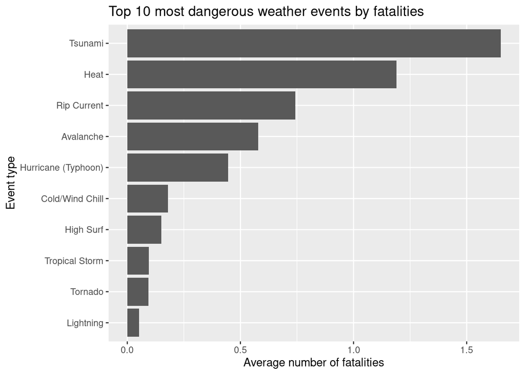

```r
final_storms_data %>%
    group_by(event_type) %>%
    summarise(avg_fatalities = mean(fatalities)) %>%
    arrange(desc(avg_fatalities)) %>%
    # select top 10 event types with the most fatalities
    head(10) %>%
    ggplot(aes(x = reorder(event_type, avg_fatalities), y = avg_fatalities)) +
    geom_bar(stat = "identity") +
    labs(title = "Top 10 most dangerous weather events by fatalities",
         x = "Event type", y = "Average number of fatalities") +
    coord_flip()
```

Looking at the above bar plot, it is clear that on average, **tsunamis** and **heat waves** cause more deaths than other weather events.

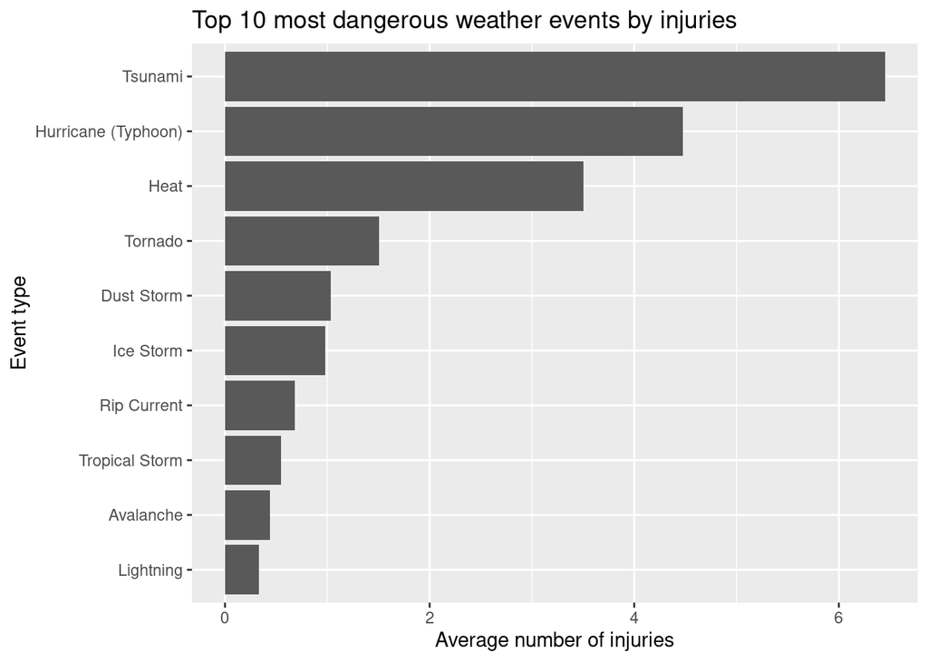

```r
final_storms_data %>%
    group_by(event_type) %>%
    summarise(avg_injuries = mean(injuries)) %>%
    arrange(desc(avg_injuries)) %>%
    # select top 10 event types with the most injuries
    head(10) %>%
    ggplot(aes(x = reorder(event_type, avg_injuries), y = avg_injuries)) +
    geom_bar(stat = "identity") +
    labs(title = "Top 10 most dangerous weather events by injuries",
         x = "Event type", y = "Average number of injuries") +
    coord_flip()
```

Looking at the average number of injuries for each event type, again **tsunami** is at the top, but this time followed by **hurricanes/typhoons**, **heat waves** and others.

Thus, **tsunamis** and **heat waves** are 2 of the most dangerous weather events with respect to the population health.

### Weather events with the greatest economic consequences

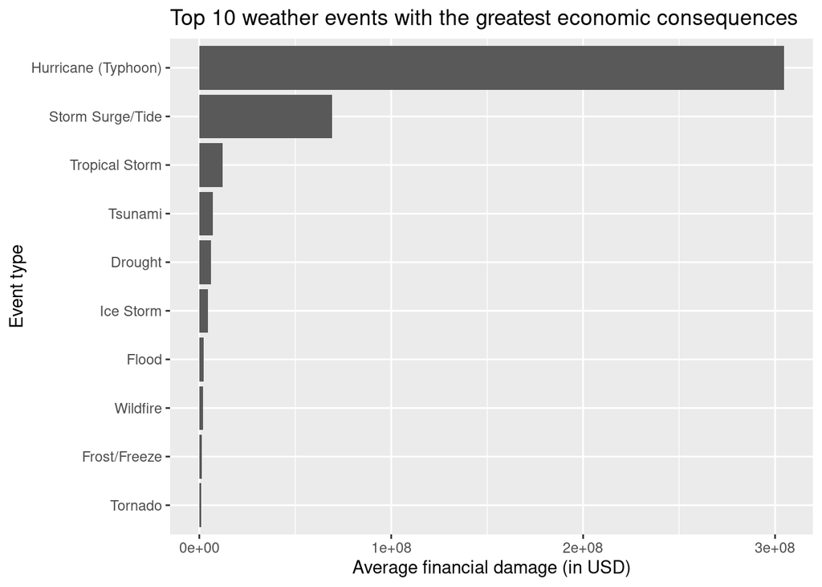

```r
final_storms_data %>%
    # sum property and crop damage
    mutate(total_damage = property_damage + crop_damage) %>%
    group_by(event_type) %>%
    summarise(avg_damage = mean(total_damage)) %>%
    arrange(desc(avg_damage)) %>%
    # select top 10 event types with the most financial damages
    head(10) %>%
    ggplot(aes(x = reorder(event_type, avg_damage), y = avg_damage)) +
    geom_bar(stat = "identity") +
    labs(title = "Top 10 weather events with the greatest economic consequences",
         x = "Event type", y = "Average financial damage (in USD)") +
    coord_flip()
```

After adding property damage and crop damage together, then taking the average of this total financial damage for each weather event type, it is clear that **hurricanes/typhoons** cause the most financial damage on average, and thus have the greatest economic consequences.